# Part II - Effect of experience level on salary over years

## by Cedric Aubin

## Investigation Overview

In this investigation, we wanted to look at the factors that affect the salary over year in the data science industry. The main focus was on experience level and work year.

## Dataset Overview

The salaries dataset we will work with is from [ai-jobs](https://salaries.ai-jobs.net/download/). Ai-jobs collects salary information anonymously from professionals all over the world in the AI/ML and Big Data space and makes it publicly available for anyone to use, share and play around with. The data is being updated regularly with new data coming in, usually on a weekly basis. The primary goal is to have data that can provide better guidance in regards to what's being paid globally. So newbies, experienced pros, hiring managers, recruiters and also startup founders or people wanting to make a career switch can make better informed decisions.

## Distribution of salaries

Salary has a right-skewed distribution. The distribution is made up of peaks with the highest around 100000 dollars and steep jumps. The discontinuity above 285000 dollars on the graph emphasizes the gap or difference between top salaries and others in the data science industry.

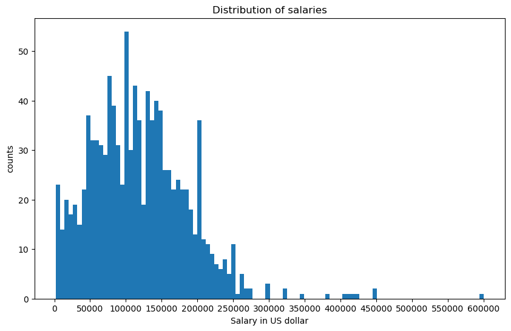

## Salary vs Experience level

Plotting salary against experience level produces a strong linear relationship. As experience level increases from the lower of entery level to the highest at Executive-level/Director the salary increases too even though there are outliners who don't follow the trend.

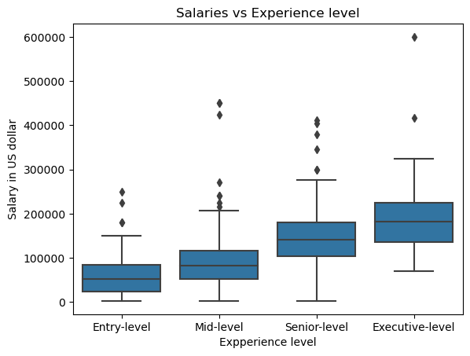

## Salary vs Work year

Weaker than the relationship between salary and experience level, salary also has a positive linear relation with work year. Globally salaries increases with years though not at the same rate.

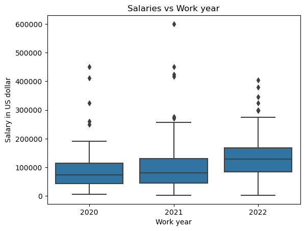

## Salary by experience level and work year

From the box plot it is difficult to clearly see the changes between salary and experience level over year, especially for 2020 and 2021. With the propability density on the violin plot, we notice that for each experience level, the probability density increases over years.

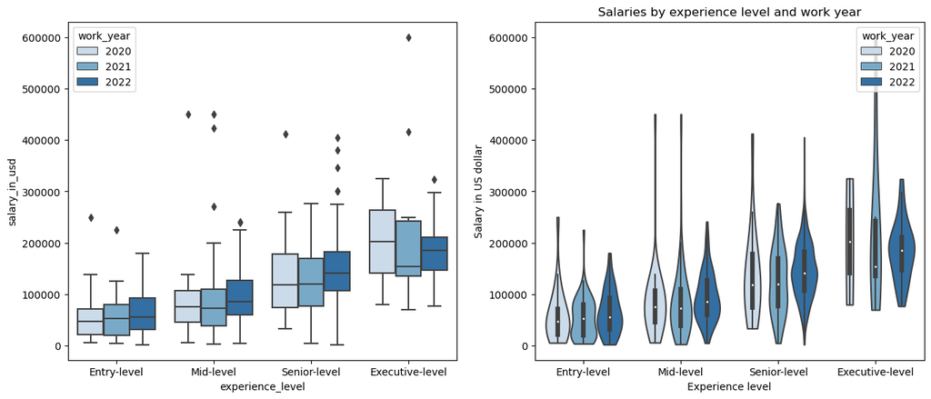

## Salary by experience level and work year for the top 10 job titles

When we consider only the top 10 job titles which make 78.31% of our dataset, we notice that only 2022 have Executive-level / Director rows. With the probability density and the position of the median on the violin plot of the top 10 job titles we observe an increase in the salary as we move lower experience level to the higher experience level over years.

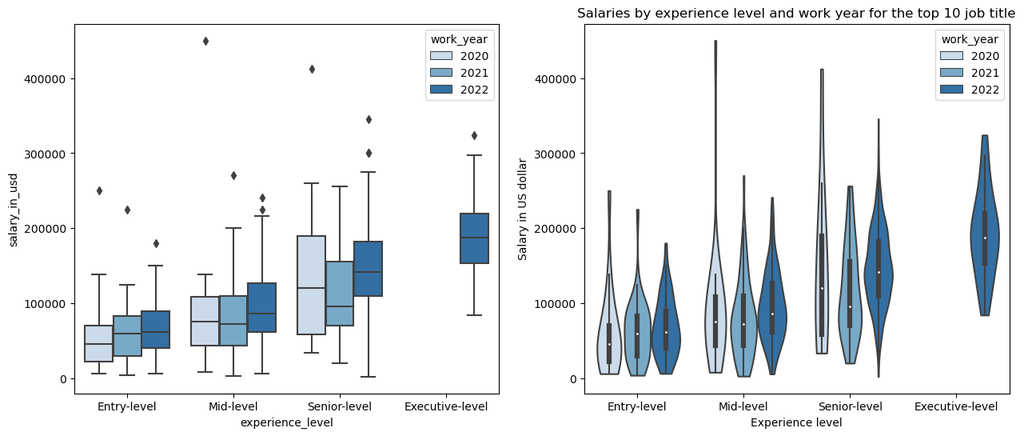